# COMPSCIX 415.2 Homework 4

Shan Valleru

2/24/2019

My Github repository for my assignments can be found at this URL: https://github.com/svalleru/compscix-415-2-assignments

```r
library(tidyverse)
library(dplyr)
library(nycflights13)
```

**Section 5.6.7: #2, #4 and #6 only. Extra Credit: Do #5**

2.Come up with another approach that will give you the same output as `not_cancelled %>% count(dest)` and `not_cancelled %>% count(tailnum, wt = distance)` (without using `count()`).

```r
flights %>%
  filter(!is.na(dep_delay) & !is.na(arr_delay)) %>%
  group_by(dest) %>% summarize(n = n())
```

```
## # A tibble: 104 x 2
##    dest      n
##    <chr> <int>
##  1 ABQ     254
##  2 ACK     264
##  3 ALB     418
##  4 ANC       8
##  5 ATL   16837
##  6 AUS    2411
##  7 AVL     261
##  8 BDL     412
##  9 BGR     358
## 10 BHM     269
## # … with 94 more rows
```

```r
flights %>%
  filter(!is.na(dep_delay) & !is.na(arr_delay)) %>%
  group_by(tailnum) %>% summarize(n = sum(distance, na.rm = TRUE))
```

```
## # A tibble: 4,037 x 2
##    tailnum      n
##    <chr>    <dbl>
##  1 D942DN    3418
##  2 N0EGMQ  239143
##  3 N10156  109664
##  4 N102UW   25722
##  5 N103US   24619
##  6 N104UW   24616
##  7 N10575  139903
##  8 N105UW   23618
##  9 N107US   21677
## 10 N108UW   32070
## # … with 4,027 more rows
```

4.Look at the number of cancelled flights per day. Is there a pattern? Is the proportion of cancelled flights related to the average delay?

```r
delayed_cancelled <-  flights %>% group_by(month, day) %>%
  summarize(avg_dep_delay = mean(dep_delay, na.rm = TRUE),
            prop_cancelled = sum(is.na(dep_time)/n()))

cor(x = delayed_cancelled$avg_dep_delay, y = delayed_cancelled$prop_cancelled)
```

```
## [1] 0.5516646
```

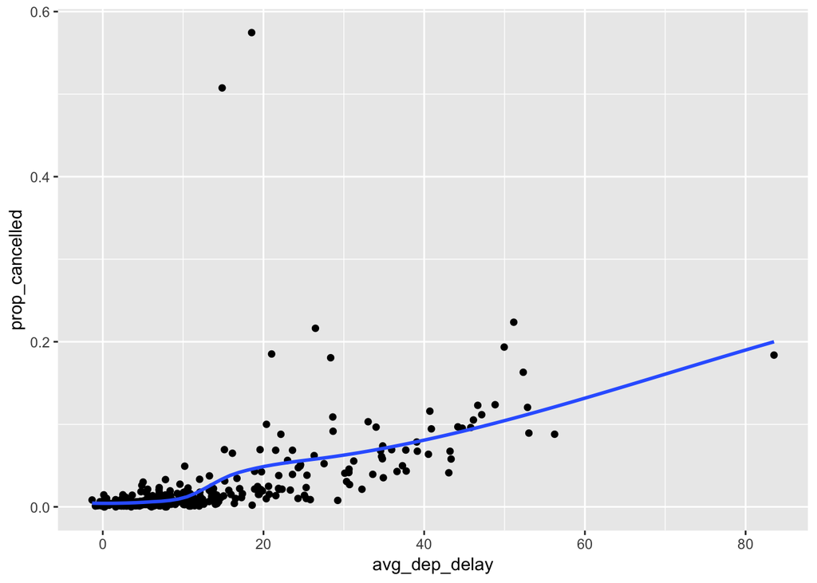

```r
ggplot(data = delayed_cancelled, mapping = aes(x = avg_dep_delay, y = prop_cancelled)) +
  geom_point() +
  geom_smooth(se = FALSE)
```

The correlation coefficient is positive(`0.5516646`), which means as the avergae departure delay increases, the more likely the flight is to be cancelled. This can also be see in the scatterplot.

6.What does the `sort` argument to `count()` do. When might you use it?

```r
?dplyr::count
```

`sort` if `TRUE` will sort output in descending order of `n`

[Extra credit] 5.Which carrier has the worst delays? Challenge: can you disentangle the effects of bad airports vs. bad carriers? Why/why not? (Hint: think about `flights %>% group_by(carrier, dest) %>% summarise(n())`)

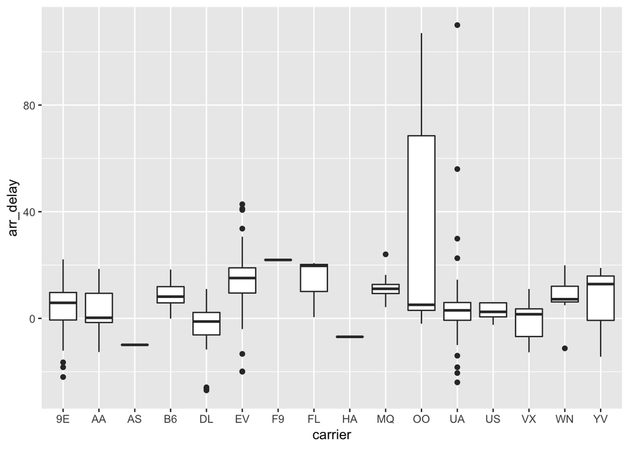

```r
carrier_delay <- flights %>%
  group_by(carrier, dest) %>%
  summarise(n = n(),
            arr_delay = mean(arr_delay, na.rm = TRUE))

ggplot(data = carrier_delay, mapping = aes(x = carrier, y = arr_delay)) +
  geom_boxplot()
```

```r
flights %>%
  group_by(carrier) %>%
  summarise(arr_delay = mean(arr_delay, na.rm = TRUE)) %>%
  arrange(desc(arr_delay))
```

```
## # A tibble: 16 x 2
##    carrier arr_delay
##    <chr>       <dbl>
##  1 F9         21.9
##  2 FL         20.1
##  3 EV         15.8
##  4 YV         15.6
##  5 OO         11.9
##  6 MQ         10.8
##  7 WN          9.65
##  8 B6          9.46
##  9 9E          7.38
## 10 UA          3.56
## 11 US          2.13
## 12 VX          1.76
## 13 DL          1.64
## 14 AA          0.364
## 15 HA         -6.92
## 16 AS         -9.93
```

Looking at the median arrival delay from the box plot and the mean arrival delay per carrier, it seems like carries with code `F9` has the worst delays.

**Section 10.5: #1, #2, #3 and #6 only**

1.How can you tell if an object is a tibble? (Hint: try printing `mtcars`, which is a regular data frame).

```r
class(mtcars)
```

```
## [1] "data.frame"
```

```r
as_tibble(mtcars)
```

```
## # A tibble: 32 x 11
##      mpg   cyl  disp    hp  drat    wt  qsec    vs    am  gear  carb
##    <dbl> <dbl> <dbl> <dbl> <dbl> <dbl> <dbl> <dbl> <dbl> <dbl> <dbl>
##  1  21       6  160    110  3.9   2.62  16.5     0     1     4     4
##  2  21       6  160    110  3.9   2.88  17.0     0     1     4     4
##  3  22.8     4  108     93  3.85  2.32  18.6     1     1     4     1
##  4  21.4     6  258    110  3.08  3.22  19.4     1     0     3     1
##  5  18.7     8  360    175  3.15  3.44  17.0     0     0     3     2
##  6  18.1     6  225    105  2.76  3.46  20.2     1     0     3     1
##  7  14.3     8  360    245  3.21  3.57  15.8     0     0     3     4
##  8  24.4     4  147.    62  3.69  3.19  20       1     0     4     2
##  9  22.8     4  141.    95  3.92  3.15  22.9     1     0     4     2
## 10  19.2     6  168.   123  3.92  3.44  18.3     1     0     4     4
## # … with 22 more rows
```

2.Compare and contrast the following operations on a `data.frame` and equivalent tibble. What is different? Why might the default data frame behaviours cause you frustration?

```r
# Data frame
df <- data.frame(abc = 1, xyz = "a")
df$x
```

```
## [1] a
## Levels: a
```

```r
df[, "xyz"]
```

```
## [1] a
## Levels: a
```

```r
df[, c("abc", "xyz")]
```

```
##   abc xyz
## 1   1   a
```

```r
# Tibble
tibl <- as_tibble(df)
tibl$x
```

[output not shown]

```r
tibl[, "xyz"]
```

```
## # A tibble: 1 x 1
##   xyz
##   <fct>
## 1 a
```

```r
tibl[, c("abc", "xyz")]
```

```
## # A tibble: 1 x 2
##     abc xyz
##   <dbl> <fct>
## 1     1 a
```

Looks like data frame is returning the column even when there’s a partial match in the name but tibble does not.

3.If you have the name of a variable stored in an object, e.g. `var <- "mpg"`, how can you extract the reference variable from a tibble?

```r
var <- "displ"
tibl <- as_tibble(mpg)
tibl$var
```

[output not shown]

```r
tibl[var]
```

```
## # A tibble: 234 x 1
##    displ
##    <dbl>
##  1   1.8
##  2   1.8
##  3   2
##  4   2
##  5   2.8
##  6   2.8
##  7   3.1
##  8   1.8
##  9   1.8
## 10   2
## # … with 224 more rows
```

```r
tibl[[var]]
```

```
##   [1] 1.8 1.8 2.0 2.0 2.8 2.8 3.1 1.8 1.8 2.0 2.0 2.8 2.8 3.1 3.1 2.8 3.1
##  [18] 4.2 5.3 5.3 5.3 5.7 6.0 5.7 5.7 6.2 6.2 7.0 5.3 5.3 5.7 6.5 2.4 2.4
##  [35] 3.1 3.5 3.6 2.4 3.0 3.3 3.3 3.3 3.3 3.3 3.8 3.8 3.8 4.0 3.7 3.7 3.9
##  [52] 3.9 4.7 4.7 4.7 5.2 5.2 3.9 4.7 4.7 4.7 5.2 5.7 5.9 4.7 4.7 4.7 4.7
##  [69] 4.7 4.7 5.2 5.2 5.7 5.9 4.6 5.4 5.4 4.0 4.0 4.0 4.0 4.6 5.0 4.2 4.2
##  [86] 4.6 4.6 4.6 5.4 5.4 3.8 3.8 4.0 4.0 4.6 4.6 4.6 4.6 5.4 1.6 1.6 1.6
## [103] 1.6 1.6 1.8 1.8 1.8 2.0 2.4 2.4 2.4 2.4 2.5 2.5 3.3 2.0 2.0 2.0 2.0
## [120] 2.7 2.7 2.7 3.0 3.7 4.0 4.7 4.7 4.7 5.7 6.1 4.0 4.2 4.4 4.6 5.4 5.4
## [137] 5.4 4.0 4.0 4.6 5.0 2.4 2.4 2.5 2.5 3.5 3.5 3.0 3.0 3.5 3.3 3.3 4.0
## [154] 5.6 3.1 3.8 3.8 3.8 5.3 2.5 2.5 2.5 2.5 2.5 2.5 2.2 2.2 2.5 2.5 2.5
## [171] 2.5 2.5 2.5 2.7 2.7 3.4 3.4 4.0 4.7 2.2 2.2 2.4 2.4 3.0 3.0 3.5 2.2
## [188] 2.2 2.4 2.4 3.0 3.0 3.3 1.8 1.8 1.8 1.8 1.8 4.7 5.7 2.7 2.7 2.7 3.4
## [205] 3.4 4.0 4.0 2.0 2.0 2.0 2.0 2.8 1.9 2.0 2.0 2.0 2.0 2.5 2.5 2.8 2.8
## [222] 1.9 1.9 2.0 2.0 2.5 2.5 1.8 1.8 2.0 2.0 2.8 2.8 3.6
```

6.What option controls how many additional column names are printed at the footer of a tibble? `tibble.max_extra_cols`: Number of extra columns printed in reduced form. Default: `100`.

**Section 12.3.3: #2, #3 and #4 only**

2.Why does this code fail?

```r
# table4a %>%
#   gather(1999, 2000, key = "year", value = "cases")
```

```
#> Error in inds_combine(.vars, ind_list): Position must be between 0 and n
```

```r
?table4a
table4a %>%
  gather("1999", "2000", key = "year", value = "cases")
```

```
## # A tibble: 6 x 3
##   country     year   cases
##   <chr>       <chr>  <int>
## 1 Afghanistan 1999     745
## 2 Brazil      1999   37737
## 3 China       1999  212258
## 4 Afghanistan 2000    2666
## 5 Brazil      2000   80488
## 6 China       2000  213766
```

Looks like gather is trying to access 1999th and 2000th columns of the data frame. Enclosing them with double quotes seems to fix it.

3.Why does spreading this tibble fail? How could you add a new column to fix the problem?

```r
people <- tribble(
  ~name,             ~key,    ~value,
  #-----------------|--------|------
  "Phillip Woods",   "age",       45,
  "Phillip Woods",   "height",   186,
  "Phillip Woods",   "age",       50,
  "Jessica Cordero", "age",       37,
  "Jessica Cordero", "height",   156
)
# spread(people, key, value)
# Error: Duplicate identifiers for rows (1, 3)
# Call `rlang::last_error()` to see a backtrace
```

I think it’s failing because it’s unable to identify rows 1 and 3 uniquely(same name and age). Adding a column that increases the entropy should fix it.

```r
people <- tribble(
  ~name,             ~key,    ~value,
  #-----------------|--------|------
  "Phillip Woods",   "age",       45,
  "Phillip Woods",   "height",   186,
  "Phillip Woods",   "age",       50,
  "Jessica Cordero", "age",       37,
  "Jessica Cordero", "height",   156
)

people <- people %>%
  group_by(name, key) %>%
  mutate(entropy = row_number())

spread(people, key, value)
```

```
## # A tibble: 3 x 4
## # Groups:   name [2]
##   name            entropy   age height
##   <chr>             <int> <dbl>  <dbl>
## 1 Jessica Cordero       1    37    156
## 2 Phillip Woods         1    45    186
## 3 Phillip Woods         2    50     NA
```

Ref: [https://www.r-bloggers.com/workaround-for-tidyrspread-with-duplicate-row-identifiers/]

4.Tidy the simple tibble below. Do you need to spread or gather it? What are the variables?

```r
preg <- tribble(
  ~pregnant, ~male, ~female,
  "yes",     NA,    10,
  "no",      20,    12
)
```

```r
preg %>%
  gather(key = 'gender', value = 'value', 2:3, na.rm = TRUE)
```

```
## # A tibble: 3 x 3
##   pregnant gender value
##   <chr>    <chr>  <dbl>
## 1 no       male      20
## 2 yes      female    10
## 3 no       female    12
```

**Section 12.4.3: #1 and #2 only**

1.What do the `extra` and `fill` arguments do in `separate()`? Experiment with the various options for the following two toy datasets.

```r
tibble(x = c("a,b,c", "d,e,f,g", "h,i,j")) %>%
  separate(x, c("one", "two", "three"))
```

```
## # A tibble: 3 x 3
##   one   two   three
##   <chr> <chr> <chr>
## 1 a     b     c
## 2 d     e     f
## 3 h     i     j
```

```r
tibble(x = c("a,b,c", "d,e", "f,g,i")) %>%
  separate(x, c("one", "two", "three"))
```

```
## # A tibble: 3 x 3
##   one   two   three
##   <chr> <chr> <chr>
## 1 a     b     c
## 2 d     e     <NA>
## 3 f     g     i
```

```r
?separate
# extra
# If sep is a character vector, this controls what happens when there are too many pieces. There are three valid options:
# "warn" (the default): emit a warning and drop extra values.
# "drop": drop any extra values without a warning.
# "merge": only splits at most length(into) times
tible <- tibble(x = c("a,b,c", "d,e,f,g", "h,i,j"))
tible %>%
  separate(x, c("one", "two", "three"), extra = 'warn')
```

```
## # A tibble: 3 x 3
##   one   two   three
##   <chr> <chr> <chr>
## 1 a     b     c
## 2 d     e     f
## 3 h     i     j
```

```r
tible %>%
  separate(x, c("one", "two", "three"), extra = 'merge')
```

```
## # A tibble: 3 x 3
##   one   two   three
##   <chr> <chr> <chr>
## 1 a     b     c
## 2 d     e     f,g
## 3 h     i     j
```

```r
tible %>%
  separate(x, c("one", "two", "three"), extra = 'drop')
```

```
## # A tibble: 3 x 3
##   one   two   three
##   <chr> <chr> <chr>
## 1 a     b     c
## 2 d     e     f
## 3 h     i     j
```

```r
# fill
# If sep is a character vector, this controls what happens when there are not enough pieces. There are three valid options:
# "warn" (the default): emit a warning and fill from the right
# "right": fill with missing values on the right
# "left": fill with missing values on the left
tible <- tibble(x = c("a,b,c", "d,e", "f,g,i"))
tible %>%
  separate(x, c("one", "two", "three"), fill = 'warn')
```

```
## # A tibble: 3 x 3
##   one   two   three
##   <chr> <chr> <chr>
## 1 a     b     c
## 2 d     e     <NA>
## 3 f     g     i
```

```r
tible %>%
  separate(x, c("one", "two", "three"), fill = 'right')
```

```
## # A tibble: 3 x 3
##   one   two   three
##   <chr> <chr> <chr>
## 1 a     b     c
## 2 d     e     <NA>
## 3 f     g     i
```

```r
tible %>%
  separate(x, c("one", "two", "three"), fill = 'left')
```

```
## # A tibble: 3 x 3
##   one   two   three
##   <chr> <chr> <chr>
## 1 a     b     c
## 2 <NA>  d     e
## 3 f     g     i
```

2.Both `unite()` and `separate()` have a `remove` argument. What does it do? Why would you set it to `FALSE`?

```r
?unite
?separate
# remove
# If TRUE, remove input columns from output data frame.
# If FALSE, keeps the old column and creates a new variable.
```

**Baby Names**

```r
file_path <- "/Users/svalleru/Desktop/UCB/COMPSCIX415.2-003 - Intro to DS/compscix-415-2-assignments/session4/baby_names.txt"
baby_names <- read_delim(file = file_path, delim = "|")
glimpse(baby_names)
```

```
## Observations: 30,000
## Variables: 5
## $ year <dbl> 1880, 1880, 1880, 1880, 1880, 1880, 1880, 1880, 1880, 1880,…
## $ sex  <chr> "F", "F", "F", "F", "F", "F", "F", "F", "F", "F", "F", "F",…
## $ name <chr> "Mary", "Anna", "Emma", "Elizabeth", "Minnie", "Margaret", …
## $ n    <dbl> 7065, 2604, 2003, 1939, 1746, 1578, 1472, 1414, 1320, 1288,…
## $ prop <dbl> 0.072384329, 0.026679234, 0.020521700, 0.019865989, 0.01788…
```

```r
new_file_path <- "/Users/svalleru/Desktop/UCB/COMPSCIX415.2-003 - Intro to DS/compscix-415-2-assignments/session4/baby_names_new.txt"
write_delim(baby_names, delim = "^", path = new_file_path)
new_baby_names <- read_delim(file = new_file_path, delim = "^")
glimpse(new_baby_names)
```

```
## Observations: 30,000
## Variables: 5
## $ year <dbl> 1880, 1880, 1880, 1880, 1880, 1880, 1880, 1880, 1880, 1880,…
## $ sex  <chr> "F", "F", "F", "F", "F", "F", "F", "F", "F", "F", "F", "F",…
## $ name <chr> "Mary", "Anna", "Emma", "Elizabeth", "Minnie", "Margaret", …
## $ n    <dbl> 7065, 2604, 2003, 1939, 1746, 1578, 1472, 1414, 1320, 1288,…
## $ prop <dbl> 0.072384329, 0.026679234, 0.020521700, 0.019865989, 0.01788…
```